# Data Preparation

2023-03-02

## Format

The focal point of our study is the Phillips Curve incorporating sticky information. The regression equation depicts inflation on the left-hand side, while the right-hand side encompasses the potentially endogenous variable – the output gap $x_t$, along with a spectrum of inflation expectations and output expectations. To estimate the model, we utilize a set of instruments denoted as $Z_t$. The required data for model estimation can be summarized as follows:
$$\begin{equation*}\pi_t = f(x_t, E_{t-1}\pi_t, ..,
E_{t-1-j}\pi_t, E_{t-1}\Delta x_t, .., E_{t-1-j}\Delta x_t).
\end{equation*}$$
and
$$\begin{equation*} Z_t =
c(1,x_{t-1},x_{t-2},x_{t-3},E_{t-1}\pi_{t+1})
\end{equation*}$$

## Inflation Expectation Data

A subset of the independent variables are historical expectations of inflation. Forecasts for the quarterly level of the chain-weighted GDP price index can be used to construct an expectation of inflation using the following formula:

The documentation from “https://www.philadelphiafed.org/-/media/frbp/assets/surveys-and-data/survey-of-professional-forecasters/spf-documentation.pdf?la=en&hash=F2D73A2CE0C3EA90E71A363719588D25”. Here for reference.

```r
E_P = read_excel("E_PGDP.xlsx");
E_P$DATE <- as.Date(as.yearqtr(paste0(E_P$YEAR, "-", E_P$QUARTER)))
E_P = transform(E_P, PGDP6 = as.numeric(PGDP6))
#head(subset(E_P, select = c(DATE, PGDP1, PGDP2, PGDP3, PGDP4, PGDP5, PGDP6)))
Y=nrow(E_P)
```

$$\begin{equation*}E_{t-1} \pi_t =
log(E_{t-1} P_t) - log(E_{t-1} P_{t-1}). \end{equation*}$$

```r
inflation  = log(E_P$PGDP2) -log(E_P$PGDP1)
```

$$\begin{equation*}E_{t-1} \pi_{t+1} =
log(E_{t-1} P_{t+1}) - log(E_{t-1} P_{t}) \end{equation*}$$

```r
pi_plus1  = log(E_P$PGDP3) -log(E_P$PGDP2)
```

$$\begin{equation*}E_{t-1} \pi_{t+2}=
log(E_{t-1} P_{t+2}) - log(E_{t-1} P_{t+1}).
\end{equation*}$$

```r
pi_plus2 = log(E_P$PGDP4) -log(E_P$PGDP3)
```

$$\begin{equation*}E_{t-1}
\pi_{t+3}= log(E_{t-1} P_{t+3}) - log(E_{t-1} P_{t+2}).
\end{equation*}$$

```r
pi_plus3  = log(E_P$PGDP5) -log(E_P$PGDP4)
```

$$\begin{equation*}E_{t-1} \pi_{t+4}=
log(E_{t-1} P_{t+4}) - log(E_{t-1} P_{t+3}).
\end{equation*}$$

```r
pi_plus4 = log(E_P$PGDP6) -log(E_P$PGDP5)
```

Now notice that we want to align the different columns according to the date on expected inflation, not the information set. We must shift the columns using NA values.

```r
expectations_inflation= data.frame(
t = E_P$DATE,
Eless1 = c(NA,inflation)[1:Y],
Eless2 = c(NA,NA,pi_plus1)[1:Y],
Eless3 = c(NA,NA,NA,pi_plus2)[1:Y],
Eless4 = c(NA,NA,NA,NA,pi_plus3)[1:Y],
Eless5 = c(NA,NA,NA,NA,NA,pi_plus4)[1:Y]
)
head(expectations_inflation,6)
```

```
##            t      Eless1      Eless2      Eless3     Eless4     Eless5
## 1 1968-10-01          NA          NA          NA         NA         NA
## 2 1969-01-01 0.008163311          NA          NA         NA         NA
## 3 1969-04-01 0.008032172 0.008097210          NA         NA         NA
## 4 1969-07-01 0.007968170 0.007968170 0.008032172         NA         NA
## 5 1969-10-01 0.015625318 0.007905180 0.007905180 0.00796817         NA
## 6 1970-01-01 0.015384919 0.007722046 0.007843177 0.00000000 0.00790518
```

Example:

In the code: Eless5 at time 1970-01-01 is equal to `log(E_P$PGDP6[1]) -log(E_P$PGDP5[1])`, where `E_P$DATE[1] = 1968-10-01`. This implies
$$\begin{equation*}E_{1968-10-01} \pi_{1970-01-01}
= log(E_{1968-10-01} P_{1970-01-01}) - log(E_{1968-10-01}
P_{1969-10-01}). \end{equation*}$$

## Output Gap Expectation Data

The Real GDP forecasts are the median from the survey of Professional Forecasters, I then assume that the forecasters know the natural rate of output.

The expected change in the output gap can be broken into two pieces given our simplifying assumption. The expectation data will form the first part. While the second part will use the actual change in the output gap.
$$\begin{equation*}E_i \alpha
\Delta x_t = \alpha*(E_i\Delta y_t - \Delta y^N_t)
\end{equation*}$$
s.t.
$$\begin{equation*}E_i\Delta y_t = log(E_{i}(Y_t))-
log(E_{i}(Y_{t-1}))\end{equation*}$$
$$\begin{equation*}\Delta y^N_t = log(Y_t^N)
-log(Y_{t-1}^N) \end{equation*}$$

```r
E_RGDP = read_excel("Median_RGDP_Level.xlsx");
E_RGDP$DATE <- as.Date(as.yearqtr(paste0(E_RGDP$YEAR, "-", E_RGDP$QUARTER)))
E_RGDP = transform(E_RGDP, RGDP6 = as.numeric(RGDP6))

#head(subset(E_RGDP, select = c(DATE, RGDP1, RGDP2, RGDP3, RGDP4, RGDP5, RGDP6)))
Y=nrow(E_RGDP)
```

$$\begin{equation*}E_{t-1} \Delta y_t =
log(E_{t-1}(Y_t))- log(E_{t-1}(Y_{t-1})) \end{equation*}$$

```r
delta_y  = log(E_RGDP$RGDP2) -log(E_RGDP$RGDP1)
```

$$\begin{equation*} E_{t-1}\Delta y_{t+1}
= log(E_{t-1}(Y_{t+1}))-
log(E_{t-1}(Y_{t})) \end{equation*}$$

```r
delta_y_plus1  = log(E_RGDP$RGDP3) -log(E_RGDP$RGDP2)
```

$$\begin{equation*} E_{t-1}\Delta y_{t+2}
= log(E_{t-1}(Y_{t+2}))-
log(E_{t-1}(Y_{t+1})) \end{equation*}$$

```r
delta_y_plus2 = log(E_RGDP$RGDP4) -log(E_RGDP$RGDP3)
```

$$\begin{equation*} E_{t-1}\Delta y_{t+3}
= log(E_{t-1}(Y_{t+3}))-
log(E_{t-1}(Y_{t+2})) \end{equation*}$$

```r
delta_y_plus3  = log(E_RGDP$RGDP5) -log(E_RGDP$RGDP4)
```

$$\begin{equation*} E_{t-1}\Delta y_{t+4}
= log(E_{t-1}(Y_{t+4}))-
log(E_{t-1}(Y_{t+3})) \end{equation*}$$

```r
delta_y_plus4 = log(E_RGDP$RGDP6) -log(E_RGDP$RGDP5)
```

Now notice that we want to align the different columns according to the date on expected inflation, not the information set. We must shift the columns using NA values.

```r
expectations_change_output= data.frame(
t = E_RGDP$DATE,
Eless1 = c(NA,delta_y)[1:Y],
Eless2 = c(NA,NA,delta_y_plus1)[1:Y],
Eless3 = c(NA,NA,NA,delta_y_plus2)[1:Y],
Eless4 = c(NA,NA,NA,NA,delta_y_plus3)[1:Y],
Eless5 = c(NA,NA,NA,NA,NA,delta_y_plus4)[1:Y]
)
head(expectations_change_output,6)
```

```
##            t       Eless1      Eless2      Eless3     Eless4      Eless5
## 1 1968-10-01           NA          NA          NA         NA          NA
## 2 1969-01-01 0.0064419844          NA          NA         NA          NA
## 3 1969-04-01 0.0076106504 0.004237903          NA         NA          NA
## 4 1969-07-01 0.0074167797 0.005812482 0.005527930         NA          NA
## 5 1969-10-01 0.0025862170 0.007246641 0.008150009 0.01060141          NA
## 6 1970-01-01 0.0003964972 0.004586767 0.006023665 0.01036515 0.009894119
```

## Realized Data

### Change in Natural Rate

Real Potential Gross Domestic Product (GDPPOT) Billions of Chained 2012 Dollars, Not Seasonally Adjusted, Frequency:Quarterly

```r
PRGDP = read_excel("PRGDP.xls");
PRGDP$DATE <- as.Date(as.yearqtr(PRGDP$observation_date))
#head(subset(PRGDP, select = c(DATE, GDPPOT)))
Y = nrow(PRGDP)
```

```r
delta_PRGDP= data.frame(
DATE = PRGDP$DATE,
delta_PRGDP = c(NA, diff(PRGDP$GDPPOT,1))
)
#head(delta_PRGDP)
```

### Output Gap

Real Gross Domestic Product (GDPC1) Billions of Chained 2012 Dollars, Seasonally Adjusted Annual Rate, Frequency:Quarterly

```r
RGDP = read_excel("RGDP.xls")
#head(RGDP)
RGDP$DATE <- as.Date(as.yearqtr(RGDP$observation_date))
#head(subset(RGDP, select = c(DATE, GDPC1 )))
Y = nrow(RGDP)
```

$$\begin{equation*}x_t =
log(Y_{t})-log(Y_t^N) \end{equation*}$$

```r
new_frame  <- merge(RGDP,PRGDP,by=c("DATE"))
new_frame$Output_Gap = log(new_frame$GDPC1)-log(new_frame$GDPPOT)
Output_Gap = data.frame(
  DATE = new_frame$DATE,
  Gap = new_frame$Output_Gap
)
#head(Output_Gap)
```

### Inflation

Gross Domestic Product: Implicit Price Deflator (GDPDEF) Index 2012=100, Seasonally Adjusted, Frequency:Quarterly

```r
GDPDEF=read_excel("GDPDEF.xls");
GDPDEF$DATE <- as.Date(as.yearqtr(GDPDEF$observation_date))
GDPDEF$log_GDPDEF=log(GDPDEF$GDPDEF)
GDPDEF$inflation = c(NA, diff(GDPDEF$log_GDPDEF, lag = 1))
#head(GDPDEF)
```

### Data Frame

```r
temporary_frame  <- merge(GDPDEF,Output_Gap,by=c("DATE"))
temporary_frame  <- merge(temporary_frame,delta_PRGDP,by=c("DATE"))

realized_variables= data.frame(
  t = temporary_frame$DATE,
  inflation = temporary_frame$inflation,
  delta_natural_output = temporary_frame$delta_PRGDP,
  output_gap = temporary_frame$Gap)

head(realized_variables, 6)
```

```
##            t     inflation delta_natural_output   output_gap
## 1 1949-01-01 -5.348424e-03                   NA  0.001401263
## 2 1949-04-01 -1.000932e-02             27.59809 -0.015046945
## 3 1949-07-01 -4.653696e-03             28.83085 -0.018210122
## 4 1949-10-01  7.773934e-05             27.54944 -0.039309137
## 5 1950-01-01 -1.478082e-03             29.23109 -0.014031887
## 6 1950-04-01  3.342015e-03             29.46911  0.002807172
```

## Survey of Data

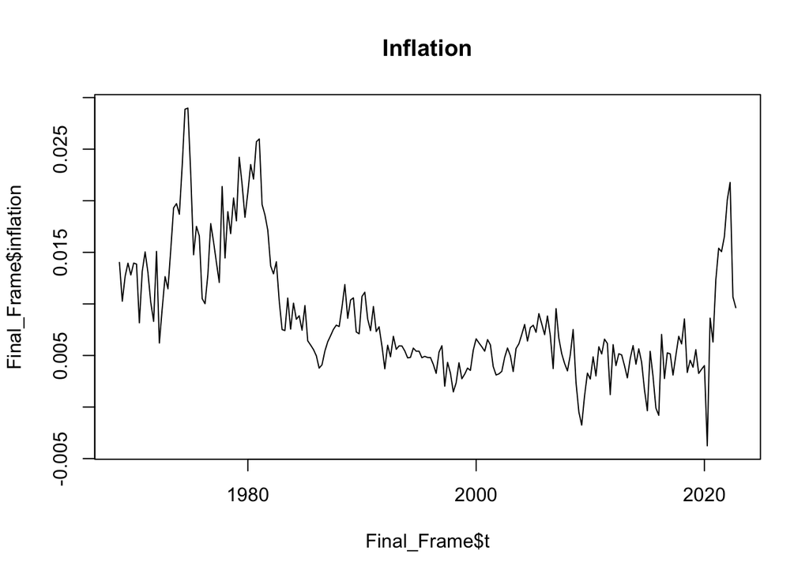

```r
Final_Frame  <- merge(realized_variables,expectations_change_output,by=c("t"))
Final_Frame  <- merge(Final_Frame,expectations_inflation,by=c("t"))

plot(Final_Frame$t,Final_Frame$inflation, main = "Inflation", type = "l")
```

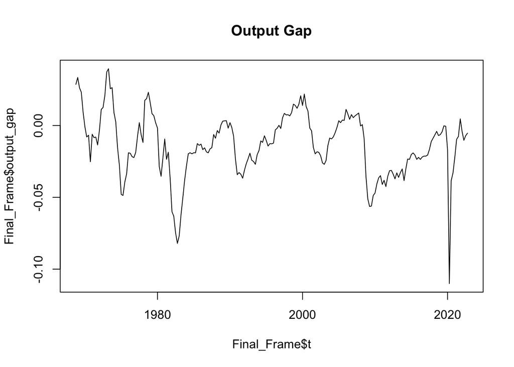

```r
plot(Final_Frame$t,Final_Frame$output_gap, main = "Output Gap", type = "l")
```

```r
MyData= Final_Frame[complete.cases(Final_Frame), ] # Removes NA
MyData = subset(MyData,MyData$t>=as.Date("1985-01-01") & MyData$t<=as.Date("2022-10-01"))
save(MyData,file="MyData.Rda") # Limit data to post 1984
```